# Lab 9

2024-03-31

Mining text data from social media. Instagram, Twitter, etc have pretty tight regulations these days (a lot has changed in the last 2 years, which is interesting), making it difficult to automate data scraping from these platforms. Reddit seems to be OK.

```r
#install.packages(c('RedditExtractoR','tidytext','dplyr','vader','wordcloud','wordcloud2'))
library(RedditExtractoR)
library(vader)
library(tidytext)
library(dplyr)
library(tidyr)
library(ggplot2)
library(wordcloud)
library(wordcloud2)
library(igraph)
library(ggraph)
```

## Part 1: Scraping text data from Reddit

```r
# Can search by subreddit
#top_urls = find_thread_urls(subreddit = 'news', sort_by = 'top')
# or by keyword
#top_urls = find_thread_urls(keywords = 'avocados', sort_by = 'top')
#head(top_urls)
```

Reduce the dataset so we’re not waiting all day

```r
#top_urls = top_urls[complete.cases(top_urls),] # this seems to be necessary bc there's one broken row
#top_urls = top_urls[1:10,]
```

The real interesting part is what people are saying about these topics - what are the comments:

```r
# This can take a long time!
#comments = get_thread_content(top_urls$url)
```

Load in data I’ve already downloaded (this took a few hours)

```r
news_threads = read.csv('data/news_threads.csv')
news_comments = read.csv('data/news_comments.csv')
news_vdf = read.csv('data/news_vdf.csv')
cats_threads = read.csv('data/cats_threads.csv')
cats_comments = read.csv('data/cats_comments.csv')
cats_vdf = read.csv('data/cats_vdf.csv')
```

## Part 2: Summarizing text data

Pre-processing: stop-words and tokenization What’s a lexicon?

```r
data("stop_words") # You will see this enter your Environment as a <Promise>
```

Word clouds

```r
# Vertical bar character is OR
remove_words = c('amp|preview.redd.it|jpeg|pjpg|webp|auto|format|width|https|\\d+')

# Have http links in text, get rid of them and re-tokenize
cats_comments$comment = gsub(remove_words, '', cats_comments$comment)


tokenized = unnest_tokens(cats_comments, word, comment)
head(tokenized, n = 10)
```

```
##    X                                                                 url
## 1  1 https://www.reddit.com/r/cats/comments/1b89gjk/senior_cat_adoption/
## 2  1 https://www.reddit.com/r/cats/comments/1b89gjk/senior_cat_adoption/
## 3  1 https://www.reddit.com/r/cats/comments/1b89gjk/senior_cat_adoption/
## 4  1 https://www.reddit.com/r/cats/comments/1b89gjk/senior_cat_adoption/
## 5  1 https://www.reddit.com/r/cats/comments/1b89gjk/senior_cat_adoption/
## 6  1 https://www.reddit.com/r/cats/comments/1b89gjk/senior_cat_adoption/
## 7  1 https://www.reddit.com/r/cats/comments/1b89gjk/senior_cat_adoption/
## 8  1 https://www.reddit.com/r/cats/comments/1b89gjk/senior_cat_adoption/
## 9  1 https://www.reddit.com/r/cats/comments/1b89gjk/senior_cat_adoption/
## 10 1 https://www.reddit.com/r/cats/comments/1b89gjk/senior_cat_adoption/
##          author       date  timestamp score upvotes downvotes golds comment_id
## 1  CollynMalkin 2024-03-06 1709759414    20      20         0     0          1
## 2  CollynMalkin 2024-03-06 1709759414    20      20         0     0          1
## 3  CollynMalkin 2024-03-06 1709759414    20      20         0     0          1
```

[output cut: 18 more lines]

```r
tokenized = anti_join(tokenized, stop_words)
```

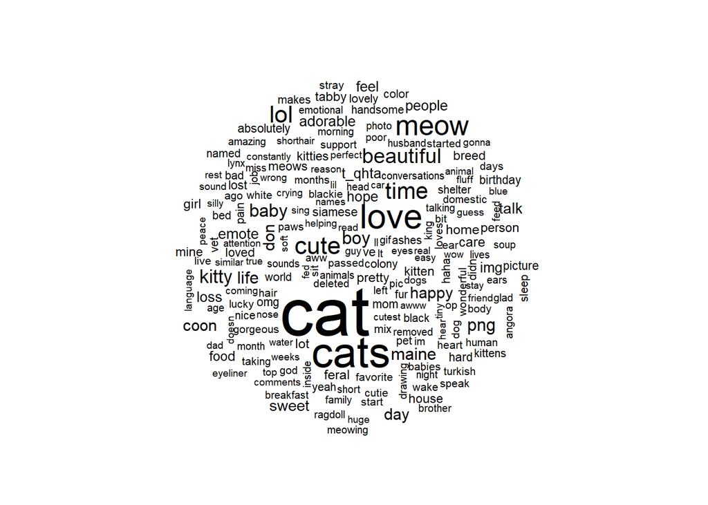

```r
counts = tokenized %>%
  count(word, sort = TRUE)

wordcloud(words = counts$word, freq = counts$n, min.freq = 2,
          max.words = 200)
```

```r
wordcloud2(data = counts)
```

[interactive chart not shown]

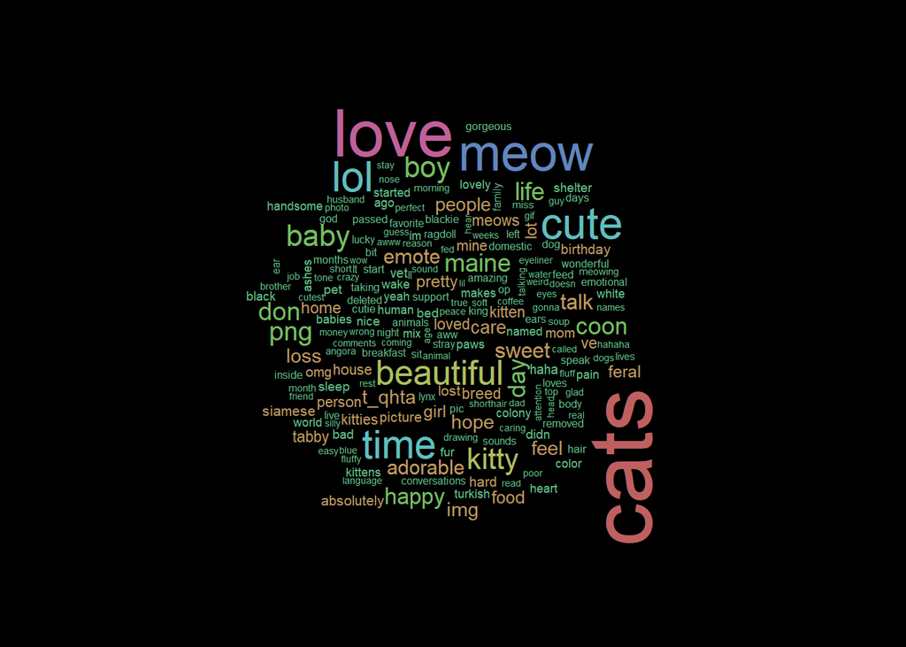

```r
# Nicer formatting
cols <- sample(rainbow(10, s = .5, v = .75), 10)

new_counts = counts[2:nrow(counts),]

## plot word cloud
par(bg = 'black')
suppressWarnings(wordcloud(
    words = new_counts$word,
    freq = new_counts$n,
    min.freq = 5,
    random.color = FALSE,
    colors = cols,
    family = "Arial",
    scale = c(4, .25),
    max.words = 200)
)
```

n-grams; networks of words

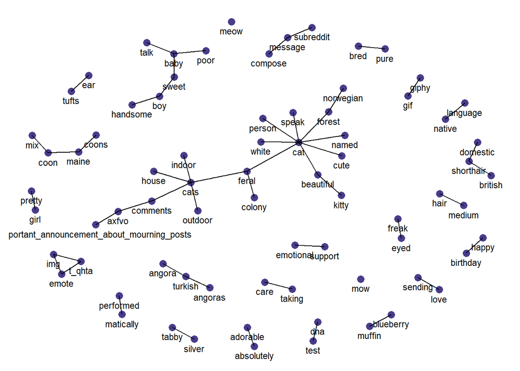

```r
bigram = unnest_tokens(cats_comments, ngram, comment, token = 'ngrams', n = 2) %>%
  separate(ngram, c("word1", "word2"), sep = " ") %>%
  filter(!word1 %in% stop_words$word) %>%
  filter(!word2 %in% stop_words$word) %>%
  count(word1, word2, sort = TRUE)

bigram = bigram[complete.cases(bigram), ]

bigram %>%
  filter(n >= 3) %>%
  graph_from_data_frame() %>%
  ggraph(layout = "fr") +
    geom_node_point(color = "darkslateblue", size = 3) +
    geom_edge_link() +
    geom_node_text(aes(label = name), vjust = 1.8, size = 3) +
    theme(panel.background = element_blank())
```

## Part 3: Linking datasets

Sentiment analysis

```r
# This can take a long time too!
#vdf = vader_df(comments$comments$comment)
```

Breakdown the comments data frame: * `text` is obviously the raw comment * `word_scores` is a word-by-word positive-to-negative value indicating sentiment * `compound` is composite score of positive/neutral/negative of comment overall * `but_count` is how many “but”’s appear in the text

Breakdown `news` and `cats`, probably some differences. These data were scraped from 3/31-4/1

Do up/down-votes differ by sentiment?

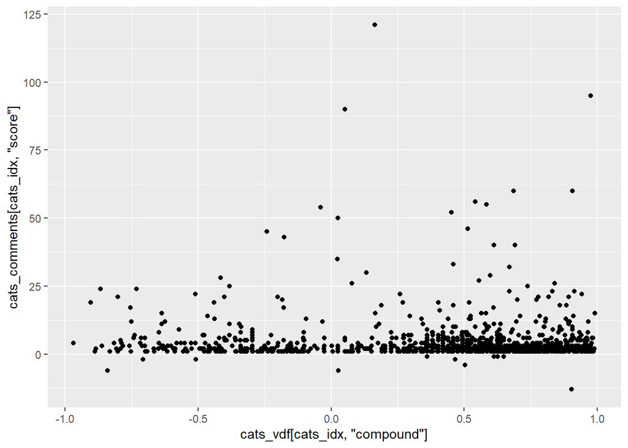

```r
# Get rows where sentiment and votes are non-zero
cats_idx = cats_vdf$compound != 0 & cats_comments$score != 0

ggplot() +
  aes(x = cats_vdf[cats_idx,'compound'],
      y = cats_comments[cats_idx,'score']) +
  geom_point()
```

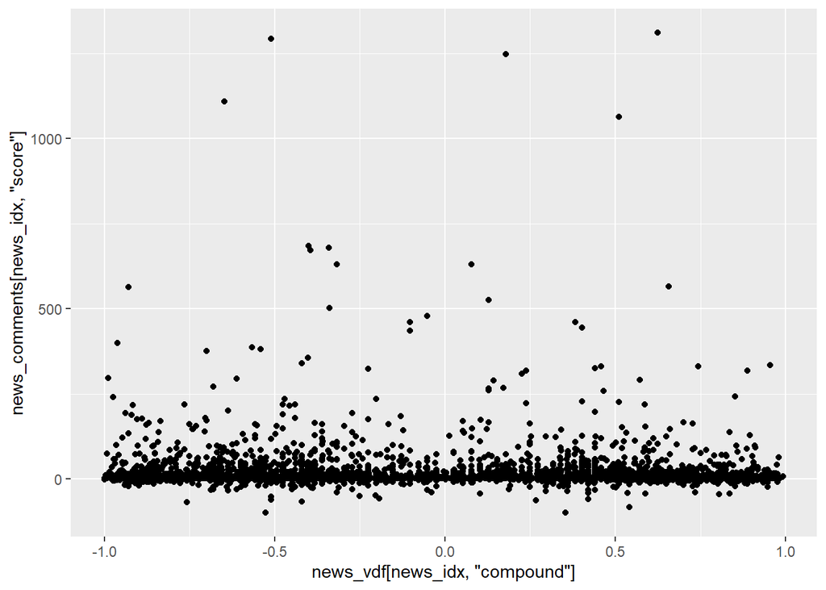

```r
# Get rows where sentiment and votes are non-zero
news_idx = news_vdf$compound != 0 & news_comments$score != 0

ggplot() +
  aes(x = news_vdf[news_idx,'compound'],
      y = news_comments[news_idx,'score']) +
  geom_point()
```